# Stochastic Gaussian Processes

# Background

The likelihood of a Multivariate Convolutional Gaussian Process (MGCP) is given as

\begin{equation} \mathcal{L}(\boldsymbol{\theta}; \mathcal{D}) = 2\pi^{-P/2} |\boldsymbol{C}_{f,f} + \boldsymbol{\Sigma}|^{-1/2} \cdot \exp(-y(\boldsymbol{C}_{f,f} + \boldsymbol{\Sigma})^{-1}y^t / 2 \end{equation}

with corresponding log-likelihood

\begin{equation} \ell(\theta; \mathcal{D}) = \ln \mathcal{L}(\theta, \mathcal{D}) \propto -y^t (C_{f,f} + \Sigma)^{-1} y - \ln |C_{f,f} + \Sigma|. \end{equation}

Learning from this likelihood requires the inversion of $\boldsymbol{C}_{f,f} + \boldsymbol{\Sigma}$ and calculating its determinant at each step/iteration. There there are computational advances that speed up this process. Despite this, for a moderate number of outputs ($N$) we suffer from a large number of parameters and an non-convex objective function.

Stochastic Gradient Descent (SGD) is a common method to combat these conditions. But SGD on Gaussian processes has been understudied because the data is correlated.

# Setup

This document examines SGD with Gaussian processes. Specifically, we are seeing how well SGD works in optimizing the likelihood function. We have a few specific questions.

- How resilient is SGD to optimization hyperparameters, like starting point and batch size?
- Does SGD work well when we add more parameters?

We use "SGD for Correlated Data" by Moyan Li as a starting point and apply the [GPyTorch](https://gpytorch.ai) package.

```python
import torch
import gpytorch
import math
import numpy as np
from matplotlib import pyplot as plt
from sklearn.metrics import mean_squared_error
from collections import defaultdict
from tqdm import tqdm

# My homemade package
import sgp

import pdb
```

## Training and Testing

```python
def trainSGD(model, likelihood, train_x, train_y, test_x, test_y,
             batch_size = 10, training_iter = 100, scheduler = None, verbose = False):

    # "Loss" for GPs - the marginal log likelihood
    mll = gpytorch.mlls.ExactMarginalLogLikelihood(likelihood, model)

    # Collection of losses and MSEs
    losses, mses, parameters = list(), list(), defaultdict(list)

    # Displaying parameters
    print(f'{model.count_parameters()} raw parameters. Initial values:')
    model.get_parameters(show = True)
    print('', flush = True)

    # Training
    for i in (range(training_iter) if verbose else tqdm(range(training_iter))):
        # Setting Training mode
        model.train()
        likelihood.train()
        # Zero gradients from previous iteration
        scheduler.optimizer.zero_grad()
        # Output from model
        minibatch = np.random.choice(train_x.shape[0], batch_size, replace = False)
        output = model(train_x[minibatch])
        # Calc loss and backprop gradients
        loss = -mll(output, train_y[minibatch])
        loss.backward()
        if verbose and (not ((i+1) % 20) or i == 0):
            print('Iter %d/%d - Loss: %.3f' % (i + 1, training_iter, loss.item()))
            model.get_parameters(show = True)
        scheduler.optimizer.step()
        # Recording actual parameters, loss, and MSE (in Evaluation Mode)
        model.eval()
        likelihood.eval()
        losses.append(loss.item())
        mses.append(mean_squared_error(test_y, model(test_x).mean.detach()))
        for k, v in model.get_parameters(raw = False).items():
            parameters[k].append(v)
        scheduler.step()

    return(losses, mses, parameters)

def test(model, likelihood, test_x):
    # Get into evaluation (predictive posterior) mode
    model.eval()
    likelihood.eval()
    # Make predictions by feeding model through likelihood
    with torch.no_grad(), gpytorch.settings.fast_pred_var():
        test_pred = likelihood(model(test_x))
        return(test_pred)

def baseline_mse(train_y, test_y):
    train_mean = torch.mean(train_y).item()
    return mean_squared_error(test_y, [train_mean for i in test_y])
```

# Simulation 1. One dimension, one parameter (from Li)

```python
def f1(x):
    return torch.div(torch.mul(x, x), 1 - x)

# Generating Data
train_x, test_x = torch.linspace(0, 0.8, 10), torch.linspace(0, 0.8, 15)
train_y, test_y = f1(train_x), f1(test_x)

# True parameter values
truths = {'covar_module.base_kernel.lengthscale':0.3}
```

```python
def simulation_1(batch_size, training_iter,
                 lr, sched_lambda = lambda epoch: 1, verbose = False, momentum = 0, nesterov = False):

    # Model Setup
    likelihood = gpytorch.likelihoods.GaussianLikelihood()
    model = sgp.models.VanillaSGP(train_x, train_y, likelihood)
    # Setting non-trained parameters to match 'one dimension, three parameters' example
    model.likelihood.noise_covar.noise = 0.1**2
    model.likelihood.noise_covar.raw_noise.requires_grad = False
    model.covar_module.outputscale = 3**2
    model.covar_module.raw_outputscale.requires_grad = False

    # Optimizer
    optimizer = torch.optim.SGD([{'params': model.parameters()}], lr = lr, momentum = momentum, nesterov = nesterov)
    scheduler = torch.optim.lr_scheduler.LambdaLR(optimizer, sched_lambda)

    # Training
    losses, mses, parameters = \
        trainSGD(model, likelihood, train_x, train_y, test_x, test_y,
                 batch_size = batch_size, training_iter = training_iter, scheduler = scheduler,
                 verbose = verbose)

    # Removing manually set parameters (and mean, since it is not of interest)
    for param_name in ['likelihood.noise_covar.noise', 'mean_module.constant', 'covar_module.outputscale']:
        parameters.pop(param_name)

    # Plotting
    f, ax = plt.subplots(1, 3, figsize = (24, 4))
    ax[0] = sgp.plotting.plot_loss(ax[0], losses)
    ax[1] = sgp.plotting.plot_mses(ax[1], mses, baseline_mse(train_y, test_y))
    ax[2] = sgp.plotting.plot_function(ax[2], train_x, train_y, test_x, test_y, test(model, likelihood, test_x))
    plt.show()
    f, ax = plt.subplots(figsize = (6, 4))
    ax = sgp.plotting.plot_parameters(ax, parameters, truths)
    plt.show()
```

```
4 Parameters to be Optimized. Initial values:
   Parameter name: likelihood.noise_covar.raw_noise           value = -4.610266208648682
   Parameter name: mean_module.constant                       value = 0.0
   Parameter name: covar_module.raw_outputscale               value = 8.999876976013184
   Parameter name: covar_module.base_kernel.raw_lengthscale   value = 0.0
```

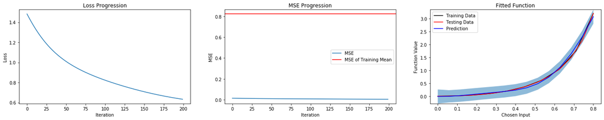

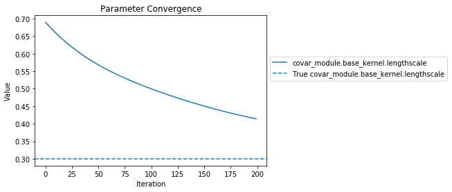

```python
# Li's hyperparameters
simulation_1(batch_size = 10, training_iter = 200, lr = 0.003)
```

```
Trial 1

4 Parameters to be Optimized. Initial values:
   Parameter name: likelihood.noise_covar.raw_noise           value = -4.610266208648682
   Parameter name: mean_module.constant                       value = 0.0
   Parameter name: covar_module.raw_outputscale               value = 8.999876976013184
   Parameter name: covar_module.base_kernel.raw_lengthscale   value = 0.0
```

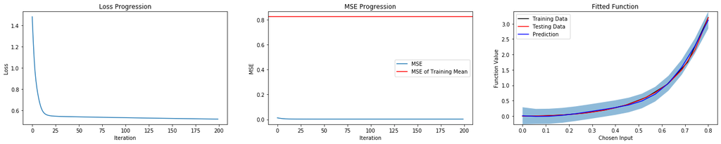

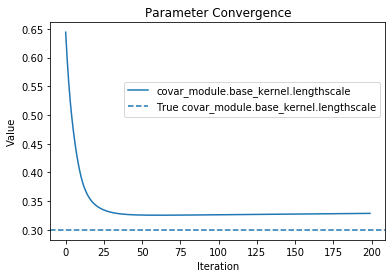

```python
# My hyperparameters
for i in range(1):
    print("Trial " + str(i + 1) + "\n")
    simulation_1(batch_size = 10, training_iter = 200, lr = 0.03, momentum = 0.5, nesterov = True)
```

## Notes

# Simulation 2. One dimension, three parameters (from Li)

```python
# Simulation specifications
n_train, n_test = 100, 999
outputscale = 4**2
lengthscale = 2
sigma = 0.1

# Genrating features
N = n_train + n_test
X = torch.linspace(0, 100, N)

# Forming covariance matrices to get targets
data_kernel = gpytorch.kernels.ScaleKernel(gpytorch.kernels.RBFKernel())
data_kernel.outputscale = outputscale
data_kernel.base_kernel.lengthscale = lengthscale
Sigma = (data_kernel(X, X) + torch.diag(torch.Tensor([sigma**2 for _ in X]))).detach().numpy()
Y = torch.Tensor(np.random.multivariate_normal(np.zeros(N), Sigma, size = 1).ravel())

# Sampling for training and testing sets
I = torch.randperm(N)
train_x, train_y = X[I[:n_train]], Y[I[:n_train]]
test_x, test_y = X[I[n_train:N]], Y[I[n_train:N]]

# Summarizing 'true' parameter values
truths = {'likelihood.noise_covar.noise':sigma**2,
          'covar_module.outputscale':data_kernel.outputscale,
          'covar_module.base_kernel.lengthscale':data_kernel.base_kernel.lengthscale}
```

```python
def simulation_2(batch_size, training_iter,
                 lr, sched_lambda = lambda epoch: 1, verbose = False, momentum = 0, nesterov = False):

    # Model Setup
    likelihood = gpytorch.likelihoods.GaussianLikelihood()
    model = sgp.models.VanillaSGP(train_x, train_y, likelihood)

    # Optimizer
    optimizer = torch.optim.SGD([{'params': model.parameters()}], lr = lr, momentum = momentum, nesterov = nesterov)
    scheduler = torch.optim.lr_scheduler.LambdaLR(optimizer, sched_lambda)

    # Training
    losses, mses, parameters = \
        trainSGD(model, likelihood, train_x, train_y, test_x, test_y,
                 batch_size = batch_size, training_iter = training_iter, scheduler = scheduler,
                 verbose = verbose)

    # Removing mean, since it is not of interest
    parameters.pop('mean_module.constant')

    # Plotting
    f, ax = plt.subplots(1, 3, figsize = (24, 4))
    ax[0] = sgp.plotting.plot_loss(ax[0], losses)
    ax[1] = sgp.plotting.plot_mses(ax[1], mses, baseline_mse(train_y, test_y))
    ax[2] = sgp.plotting.plot_function(ax[2], train_x, train_y, test_x, test_y, test(model, likelihood, test_x))
    plt.show()
    f, ax = plt.subplots(figsize = (6, 4))
    ax = sgp.plotting.plot_parameters(ax, parameters, truths)
    plt.show()
```

```
4 raw parameters. Initial values:
   Parameter name: likelihood.noise_covar.raw_noise           value = 0.0
   Parameter name: mean_module.constant                       value = 0.0
   Parameter name: covar_module.raw_outputscale               value = 0.0
   Parameter name: covar_module.base_kernel.raw_lengthscale   value = 0.0
```

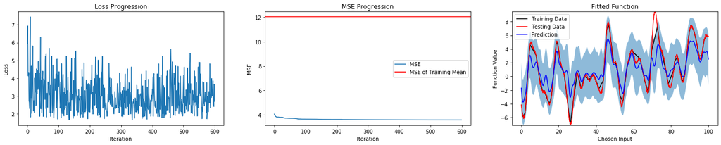

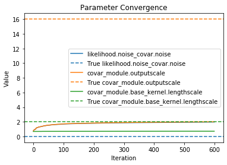

```python
# Li's hyperparameters
simulation_2(batch_size = 4, training_iter = 600, lr = 0.08, sched_lambda = lambda epoch: (np.ceil((epoch + 1) / 12)**-1))
```

```
4 raw parameters. Initial values:
   Parameter name: likelihood.noise_covar.raw_noise           value = 0.0
   Parameter name: mean_module.constant                       value = 0.0
   Parameter name: covar_module.raw_outputscale               value = 0.0
   Parameter name: covar_module.base_kernel.raw_lengthscale   value = 0.0
```

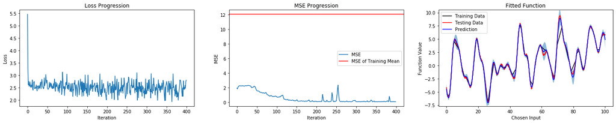

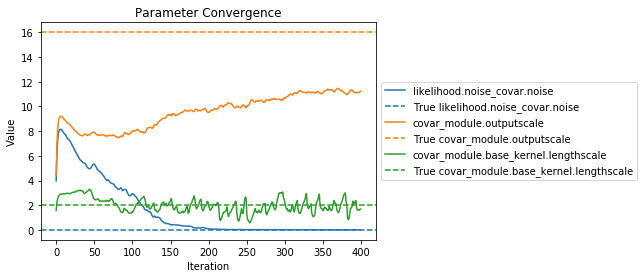

```python
# My hyperparameters
simulation_2(batch_size = 10, training_iter = 400, lr = 3, momentum = 0.5)
```

## Notes

- The training hyperparameters of Li yield decent prediction, but all parameters do not converge to their true values. This is similar to the results of Li.
- Increasing the learning rate and removing learning rate decay helps with training. Momentum helps as well.

# Simulation 3. Five dimensions, six parameters

We use a separate lengthscale for each dimension as done by Li, but modify the kernel a small amount. This is so we can easily use a default kernel from the `GPyTorch` package.

Specifically, we change the kernel from

\begin{equation} K(\boldsymbol{x}, \boldsymbol{x'}) = \sigma^2 \exp \Big( -\frac{1}{2} \sum_{i=1}^{d} \frac{|x_i - x_i'|}{l_i^2} \Big) \end{equation}

to

\begin{equation} K(\boldsymbol{x}, \boldsymbol{x'}) = \sigma^2 \exp \Big( -\frac{1}{2} \sum_{i=1}^{d} \frac{(x_i - x_i')^2}{l_i^2} \Big). \end{equation}

That is, we change $|x_i - x_i'|$ to $(x_i - x_i')^2$. This is much easier to implement in `GPyTorch`, as we just specify that we want a separate lengthscale for each direction.

```python
# True parameters
d = 5
n_train, n_test = 200, 300
l = [1, 2, 3, 4, 2]
outputscale = 4
sigma = 0.001

# Generating features
N = n_train + n_test
X = torch.Tensor(np.random.multivariate_normal(np.zeros(d), np.identity(d), size = N))

# Forming covariance matrices to get targets
data_kernel = gpytorch.kernels.ScaleKernel(gpytorch.kernels.RBFKernel(ard_num_dims = d))
data_kernel.outputscale = outputscale**2
data_kernel.base_kernel.lengthscale = torch.Tensor(l)
Sigma = (data_kernel(X, X) + torch.diag(torch.Tensor([sigma**2 for _ in X]))).detach().numpy()
Y = torch.Tensor(np.random.multivariate_normal(np.zeros(N), Sigma, size = 1).ravel())

# Sampling for training and testing sets
I = torch.randperm(N)
train_x, train_y = X[I[:n_train]], Y[I[:n_train]]
test_x, test_y = X[I[n_train:N]], Y[I[n_train:N]]

# Summarizing 'true' parameter values
truths = {'likelihood.noise_covar.noise':sigma**2,
          'covar_module.base_kernel.lengthscale_0':data_kernel.base_kernel.lengthscale[0][0],
          'covar_module.base_kernel.lengthscale_1':data_kernel.base_kernel.lengthscale[0][1],
          'covar_module.base_kernel.lengthscale_2':data_kernel.base_kernel.lengthscale[0][2],
          'covar_module.base_kernel.lengthscale_3':data_kernel.base_kernel.lengthscale[0][3],
          'covar_module.base_kernel.lengthscale_4':data_kernel.base_kernel.lengthscale[0][4]}
```

```python
def simulation_3(batch_size, training_iter,
                 lr, sched_lambda = lambda epoch: 1, verbose = False, momentum = 0, nesterov = False):

    # Model Setup
    likelihood = gpytorch.likelihoods.GaussianLikelihood()
    model = sgp.models.FlexSGP(train_x, train_y, likelihood)

    # Initializing parameters according to U(0, 1) and setting known parameter 'outputscale'
    U = torch.distributions.uniform.Uniform(0, 1)
    model.likelihood.noise_covar.noise = U.rsample()
    model.covar_module.base_kernel.lengthscale = U.rsample(torch.Size([5]))
    model.covar_module.outputscale = 3
    model.covar_module.raw_outputscale.requires_grad = False
    # TESTING: holding noise constant
    model.likelihood.noise_covar.noise = sigma
    model.likelihood.noise_covar.raw_noise.requires_grad = False

    # Optimizer
    optimizer = torch.optim.SGD([{'params': model.parameters()}], lr = lr)
    scheduler = torch.optim.lr_scheduler.LambdaLR(optimizer, sched_lambda)

    # Training
    losses, mses, parameters = \
        trainSGD(model, likelihood, train_x, train_y, test_x, test_y,
                 batch_size = batch_size, training_iter = training_iter, scheduler = scheduler,
                 verbose = verbose)

    # Removing output scale (manually set) and mean (not of interest)
    parameters.pop('mean_module.constant')
    parameters.pop('covar_module.outputscale')

    # Plotting
    f, ax = plt.subplots(1, 2, figsize = (24, 4))
    ax[0] = sgp.plotting.plot_loss(ax[0], losses)
    ax[1] = sgp.plotting.plot_mses(ax[1], mses, baseline_mse(train_y, test_y))
    plt.show()
    f, ax = plt.subplots(figsize = (6, 4))
    ax = sgp.plotting.plot_parameters(ax, parameters, truths)
    plt.show()
```

[output not shown]

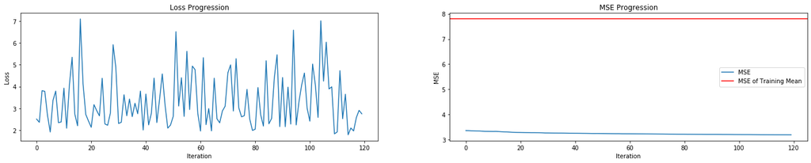

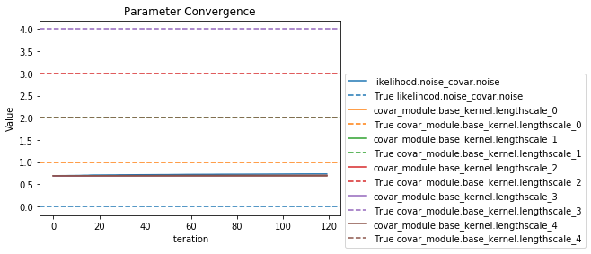

```python
# Li's hyperparameters
simulation_3(batch_size = 5, training_iter = 120, lr = 0.01, sched_lambda = lambda epoch: (np.ceil((epoch + 1) / 20))**-1)
```

```
4 raw parameters. Initial values:
   Parameter name: likelihood.noise_covar.raw_noise           value = -7.012665748596191
   Parameter name: mean_module.constant                       value = 0.0
   Parameter name: covar_module.raw_outputscale               value = 2.9489307403564453
   Parameter name: covar_module.base_kernel.raw_lengthscale   value = tensor([-0.6626,  0.0323, -4.9843, -1.1783,  0.4886])
```

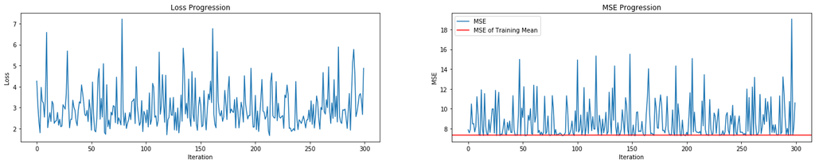

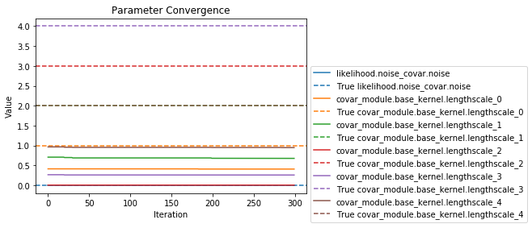

```python
# My hyperparameters
simulation_3(batch_size = 5, training_iter = 300, lr = 3, momentum = 0.5)
```

## Notes

# General Notes